# A short primer on the Manifesto Project and its methodology

Manifesto Project Team, manifesto-communication@wzb.eu

25 April, 2018

This introduction should give a brief overview of the Manifesto Project methodology as well as illustrate the structure of the Manifesto Project Main Dataset and the Manifesto Corpus.[^1]

The Manifesto Project collects and analyzes parties’ electoral programs (manifestos). It’s data collection is publicly available and forms the basis for many [publications in political science and other disciplines](https://manifesto-project.wzb.eu/publications/all). Since 2009, the Manifesto Project is funded by the German Research Foundation under the name Manifesto Research on Political Representation (MARPOR) and is located the WZB Berlin Social Science Center. MARPOR continues the work and data collection of the Comparative Manifestos Project and the Manifesto Research Group that go back until 1979.

# Methodology

## Training and Rules

The coding (or annotation as it is also called) is conducted by country experts. The coding follows strict rules that are described in detail in the coding instructions. Despite the long history of the project, the general coding methodology has only slightly changed over time which makes the data comparable over time. The [current version of the coding instructions](https://manifesto-project.wzb.eu/information/documents/handbooks) can be found on the website.[^6]

The country expert coders are mostly political scientist or political science students and native speakers. They were trained to parse and code the documents according to the rules specified in the coding instructions. The expert training is done in English on two training documents. Only if the coding results in these documents surpass a certain level of accuracy, the coder will be asked to code the documents from his or her own country.

## Coding Unit

The coding usually encompasses the entire text of a party’s electoral programs. Only a few parts are excluded: preambles, text in tables and pictures, and headlines. The first step of the coding process is the unitization of the document. All text is split into so-called quasi-sentences - the general coding unit of the Manifesto Project. *A quasi-sentence is a single statement. A grammatical sentence can contain more than one quasi sentence, but a quasi-sentence can never span over more than one grammatical sentence.* The following example illustrates this process in more detail. The extract below is takem from the 2012 manifesto of the Democratic Party in the US.

> […] President Obama has already signed into law $2 trillion in spending reductions as part of a balanced plan to reduce our deficits by over $4 trillion over the next decade while taking immediate steps to strengthen the economy now. This approach includes tough spending cuts that will bring annual domestic spending to its lowest level as a share of the economy in 50 years, while still allowing us to make investments that benefit the middle class now and reduce our deficit over a decade. […]

> — Democratic Party (US), Extract from 2012 Electoral Platform

The extract shows the text before the unitization process. The next extract illustrates the extract after the unitization. The coder added two slashes (//) between all quasi-sentences to indicate the end of one and the start of the following quasi-sentence.

> […] President Obama has already signed into law $2 trillion in spending reductions as part of a balanced plan to reduce our deficits by over $4 trillion over the next decade **//** while taking immediate steps to strengthen the economy now. **//** This approach includes tough spending cuts that will bring annual domestic spending to its lowest level as a share of the economy in 50 years, **//** while still allowing us to make investments that benefit the middle class now **//** and reduce our deficit over a decade. […]

> — Democratic Party (US), Extract from 2012 Electoral Platform

This illustrates well that almost the entire text is split into quasi-sentences.

Three important remarks about the coding unit:

- **The coding unit is the quasi-sentence. One quasi-sentence equals one statement.**
- **A grammatical sentence can contain several quasi-sentences, but a quasi-sentence should never span over more than one grammatical sentence.**
- **Almost all text is parsed into quasi-sentences (exceptions are the preamble and headlines).**

## Code Allocation

In a next step the text is transformed into a table where each row contains one quasi-sentence. Then the quasi-sentences are allocated to codes. These codes belong to a category scheme that covers a broad range of policy issues. The following table lists the major codes of the category scheme:

| code | category | description |
| --- | --- | --- |
| 000 | Uncoded | Quasi-sentences that do not fit any other category |
| 101 | Foreign Special Relationships: Positive | Favourable mentions of particular countries with which the manifesto country has a special relationship; the need for co-operation with and/or aid to such countries. |
| 102 | Foreign Special Relationships: Negative | Negative mentions of particular countries with which the manifesto country has a special relationship. |
| 103 | Anti-Imperialism | Negative references to imperial behaviour and/or negative references to one state exerting strong influence (political, military or commercial) over other states. May also inclu... |
| 104 | Military: Positive | The importance of external security and defence. May include statements concerning: - The need to maintain or increase military expenditure; - The need to secure adequate ... |
| 105 | Military: Negative | Negative references to the military or use of military power to solve conflicts. References to the ‘evils of war’. May include references to: - Decreasing military expenditur... |
| 106 | Peace | Any declaration of belief in peace and peaceful means of solving crises – absent reference to the military. May include: - Peace as a general goal; - Desirability of count... |
| 107 | Internationalism: Positive | Need for international co-operation, including co-operation with specific countries other than those coded in 101. May also include references to the: - Need for aid to devel... |
| 108 | European Community/Union: Positive | Favourable mentions of European Community/Union in general. May include the: - Desirability of the manifesto country joining (or remaining a member); - Desirability of... |
| 109 | Internationalism: Negative | Negative references to international co-operation. Favourable mentions of national independence and sovereignty with regard to the manifesto country’s foreign policy, isolation ... |

[output cut: 47 more lines]

The three most important coding rules are:

- **One (and only one) code should assigned to each quasi-sentence.**
- **The coding of policy goals precedes over the coding of political means if both are mentioned in one quasi-sentence.**
- **Coders should use as little context and personal knowledge as necessary to decide about the code of a quasi-sentence.**

The extract shown above from the electoral program of the Democratic Party looks like following after the coding:

| quasi_sentence | category | description |
| --- | --- | --- |
| President Obama has already signed into law $2 trillion in spending reductions as part of a balanced plan to reduce our deficits by over $4 trillion over the next decade | 414 | Economic Orthodoxy |
| while taking immediate steps to strengthen the economy now. | 408 | Economic Goals |
| This approach includes tough spending cuts that will bring annual domestic spending to its lowest level as a share of the economy in 50 years, | 414 | Economic Orthodoxy |
| while still allowing us to make investments that benefit the middle class now | 704 | Middle Class and Professional Groups |
| and reduce our deficit over a decade. | 414 | Economic Orthodoxy |

One code is allocated to each quasi-sentence that reflects the policy goal or issue mentioned in the statement. In essence, the coding methodology has only slightly changed since the begin of the Manifesto Project in 1979. A major change is that since 2009 the coding of quasi-sentences is done on the computer instead of on printed copies of the documents.

# Manifesto Project Dataset (Main Dataset)

The Manifesto Project Main Dataset was first published in 2001 with the book Mapping Policy Preferences I (Budge et al. 2001). Since 2009 the dataset is available online.

## Structure of the Main Dataset

- **Each row in the dataset represents one electoral program.**
- **The perXXX variables indicate the share (per-centage) of quasi-sentences related to the focal category.**
- **The variables party and date jointly uniquely identify every row in the dataset.**

See below for a simplified version of the dataset with the most important variables. *Country* and *countryname* as well as *edate* and *date* identify the specific country and election in and for which the manifesto was published. The variable *party* is an identifier variable. *partyname* is a party’s name in English. The total variable indicates the number of quasi-sentences in the manifesto. The per-variables indicate the share of quasi-sentences related to eacht code. A value of 0.586 for the variable per101 for the manifesto of the Democratic Party means that 0.59% of quasi-sentences were coded as 101 (positive mentionings about a party’s foreign Relationships with a specific country). The peruncod indicates the share of sentences that were coded with the code 000 that is applied to quasi-sentences were no other code fits.

| country | countryname | edate | date | party | partyname | total | peruncod | per101 | per102 | per103 | per104 | per105 | per106 | per107 | per108 | per109 | per110 | per201 | per202 | per203 | per204 | per301 | per302 | per303 | per304 | per305 | per401 | per402 | per403 | … |
| --- | --- | --- | --- | --- | --- | --- | --- | --- | --- | --- | --- | --- | --- | --- | --- | --- | --- | --- | --- | --- | --- | --- | --- | --- | --- | --- | --- | --- | --- | --- |
| 61 | United States | 2012-11-06 | 201211 | 61320 | Democratic Party | 1366 | 3.734 | 0.586 | 0.146 | 0.366 | 7.028 | 2.489 | 0.659 | 9.883 | 0 | 0 | 0 | 3.441 | 3.294 | 0.439 | 0.073 | 1.098 | 0.073 | 2.269 | 1.098 | 3.66 | 0.586 | 2.928 | 4.392 | … |
| 61 | United States | 2012-11-06 | 201211 | 61620 | Republican Party | 1674 | 5.735 | 0.418 | 0.179 | 0 | 8.065 | 0.418 | 0.657 | 1.971 | 0 | 1.195 | 0.06 | 3.823 | 3.883 | 2.449 | 0.597 | 4.839 | 0.119 | 4.361 | 0.777 | 3.166 | 5.854 | 1.374 | 1.075 | … |

Note that you can scroll the table above horizontally. Please also be aware that the table above is a very simplified version of the dataset. The real dataset includes many more variables. The ones shown above are the most central variables in the dataset.

Note also that the dataset files for Stata and SPSS contain labels for variables and values whenever this is reasonable and therefore might look slightly different than shown here. A following tutorial will deal with the question how the Manifesto Project Main Dataest can be used to measure parties’ political preferences.

## Coverage of the Main Dataset

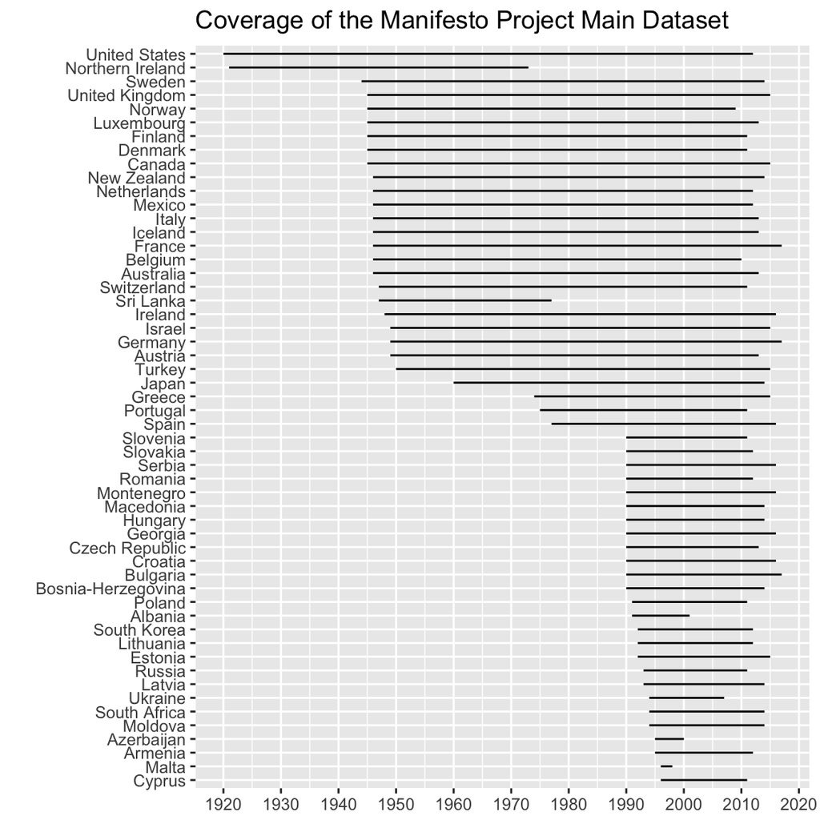

## Access to the Main Dataset

The Manifesto Project Main Dataset can be accessed in different ways:

- You can [**download it from the Manifesto Project Website**](https://manifesto-project.wzb.eu/datasets). Different file formats are available: .xlsx for Excel, .dta for Stata, .sav for SPSS, .csv as [comma-separated values](https://en.wikipedia.org/wiki/Comma-separated_values). To be able to download the dataset, you need to login on the website. Login is possible after having registered. Registration is free, simple and quick.
- You can [**browse it online**](https://visuals.manifesto-project.wzb.eu/mpdb-shiny/cmp_dashboard_dataset/). The online dashboard is convenient for simple analysis, but does not offer the same analytical possibilites as a statistical software packages such as R, Stata or SPSS.
- You can access the dataset directly in R or Stata using the Manifesto Project add-ons: [**manifestoR**](https://manifesto-project.wzb.eu/information/documents/manifestoR) and [**manifestata**](https://manifesto-project.wzb.eu/information/documents/manifestata). This circumvents the download from the website and instead conveniently loads the dataset directly in the software in a less error-prone manner.

# The Manifesto Corpus

- **The Manifesto Corpus is a digital text collection of electoral programs based on the collection and coding that was conducted for the generation of the Manifesto Project Main dataset.**
- **The Manifesto Corpus contains three types of informations: machine-readable texts, meta-information for each document (such as language and title), and (for some documents) annotations/codes on the quasi-sentence level.**
- **The Manifesto Corpus uses the same identifier variables as the Manifesto Main dataset so that data from Corpus and Dataset can be easily linked - but machine-readable texts and annotations are not available for all manifestos that are covered by the Main dataset.**

## Structure of the Manifesto Corpus

The coverage of the Manifesto Corpus and the Manifesto Project Main Dataset are not exacly congruent. As in the past, the coding was done on printed copies, not all manifestos are available as digital texts. In particular, the codings are not always available digitally in the Manifesto Corpus. The Manifesto Corpus contains different types of documents:

- machine-readable electoral programs, or
- annotated documents (machine-readable electoral programs parsed into quasi-sentences and accompanied by codes)

Moreover, the meta-data of each document contain links to the pdf on our server to the scanned or downloaded copies of the original programs. The following shows a simplified version of the meta-data table for all manifestos of the Republican party in the US since 1980. The party variable indicates a party identifier (the same that is used in the Main dataset). The language refers to the language of the column. This can be useful for filtering documents for one or specific languages. The column annotation indicates whether a document is parsed into quasi-sentences and contains annotations or not. The “source” column refers to the project by which the document was collected.[^7]

MARPOR refers to the current funding of Manifesto project. You can find more details on all other meta-information on the Manifesto Corpus website.

| party | date | language | source | annotations | title |
| --- | --- | --- | --- | --- | --- |
| 61620 | 198011 | english | CEMP | False | Republican Party Platform 1980 |
| 61620 | 198411 | english | CEMP | False | 1984 Republican platform |
| 61620 | 198811 | english | CEMP | False | An American vision. For our children and our future |
| 61620 | 199211 | english | CEMP | False | Republican Party platform 1992 |
| 61620 | 199611 | english | CEMP | False | The 1996 Republican platform |
| 61620 | 200011 | english | CEMP | False | Republican Platform 2000. Renewing America’s Purpose. Together. |
| 61620 | 200411 | english | MARPOR | True | 2004 Republican Party Platform: A Safer World and a More Hopeful America |
| 61620 | 200811 | english | MARPOR | True | 2008 Republican Platform |
| 61620 | 201211 | english | MARPOR | True | We believe in America. Republican Platform |

The following table shows exemplarily how information for each document is stored. This is a document that has annotations==TRUE, so that is parsed into quasi-sentences and comes along with codes next to each quasi-sentence.

| pos | text | cmp_code |
| --- | --- | --- |
| 1 | Moving America Forward 2012 Democratic National Platform |  |
| 2 | Moving America Forward |  |
| 3 | Four years ago, Democrats, independents, and many Republicans came together as Americans to move our country forward. | 0 |
| 4 | We were in the midst of the greatest economic crisis since the Great Depression, | 408 |
| 5 | the previous administration had put two wars on our nation’s credit card, | 305 |
| 6 | and the American Dream had slipped out of reach for too many. | 601 |
| 7 | Today, our economy is growing again, | 408 |
| 8 | al-Qaeda is weaker than at any point since 9/11, | 104 |
| 9 | and our manufacturing sector is growing for the first time in more than a decade. | 410 |
| 10 | But there is more we need to do, and so we come together again to continue what we started. | 0 |

[output cut: 1385 more lines]

One can see that the two first quasi-sentences do not have codes, that is because these are the title of the document and a headline. The number of rows in this document slightly differs from the value in the total column in the Main Dataset table above because for the total variable in the Main Dataset we only count sentences with codes (including 0 codes).

## Coverage of the Manifesto Corpus

Due to the history of the Manifesto Project, not all manifestos are available in a machine-readable format with digital codings. The following graphs illustrates the coverage of the Manifesto Corpus relative to the coverage of the Main Dataset (see figure above) in regard to whether documents are available in machine-readable format and whether documents are digitally annotated.

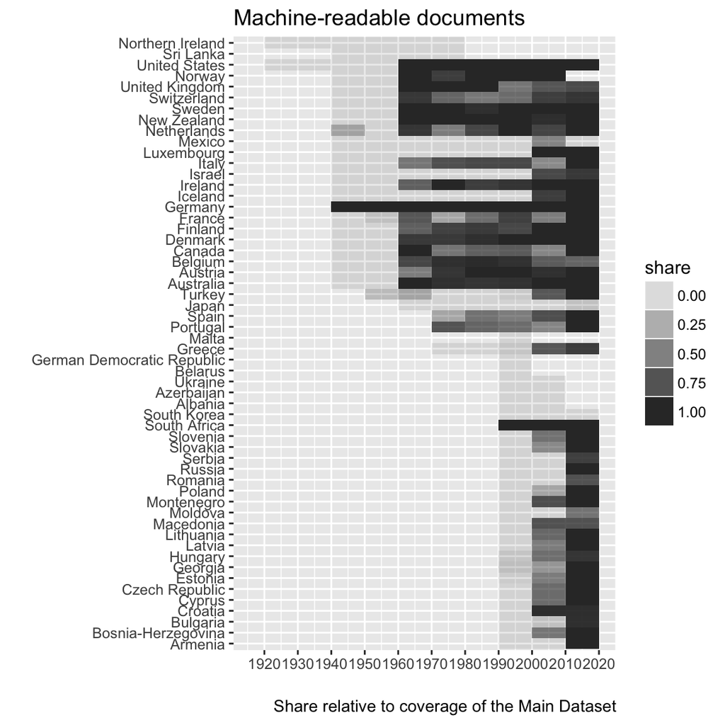

Annotated and machine-readable documents (relative to the coverage of Main Dataset)

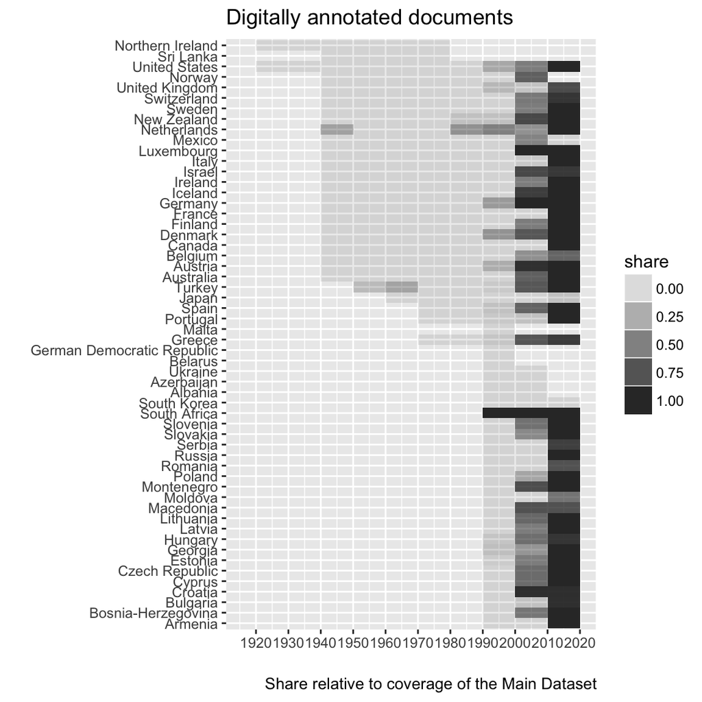

Annotated and machine-readable documents (relative to the coverage of Main Dataset)

## Access to the Manifesto Corpus

- **Explore online**: Browse the corpus online in your browser [by document](https://visuals.manifesto-project.wzb.eu/mpdb-shiny/cmp_dashboard_corpus_doc/) or [by keyword](https://visuals.manifesto-project.wzb.eu/mpdb-shiny/cmp_dashboard_corpus/).
- **[Download csv documents](https://visuals.manifesto-project.wzb.eu/mpdb-shiny/cmp_dashboard_dataset/)**: Download individual electoral programmes in .csv format. These are encoded in UTF-8. Make sure to import them correctly. You need to login (or register) to be able to download documents.
- **[Access using manifestoR](https://manifesto-project.wzb.eu/information/documents/manifestoR)**: We offer an R package that facilitates downloading and processing the Manifesto Corpus. It allows bulk downloading several documents at once and transforms the downloaded data into a corpus format. You need an API-key to be able to download documents with manifestoR. Login and create the key on your profile page.
- **[Access using manifestata](https://manifesto-project.wzb.eu/information/documents/manifestata)**: We offer a stata add-on that facilitates downloading and processing the Manifesto Corpus. It allows bulk downloading several documents at once. You need an API-key to be able to download documents with manifestoR. Login and create the key on your profile page.
- **[Access via API](https://manifesto-project.wzb.eu/information/documents/api)**: You are a programmer and would like to have direct access to our database? Our API returns all data in our database in a standardised JSON format. You need an API-key to be able to use the API. Login and create the key on your profile page.

# Further resources

Dataset documentation:

- [Coding Instructions](https://manifesto-project.wzb.eu/information/documents/handbooks) - the coding instructions state in detail the coding rules and coding scheme.
- [Dataset codebook](https://manifesto-project.wzb.eu/datasets) - the data set codebook describes the content and type of all variables included in the main dataset.
- [Release Notes of the Dataset](https://manifesto-project.wzb.eu/down/data/2017b/codebooks/release_notes_2017b.pdf) - the release notes inform about changes between different dataset versions.

Recommended project publications:

- Merz, N., Regel, S., & Lewandowski, J. (2016). The Manifesto Corpus: A new resource for research on political parties and quantitative text analysis. Research & Politics, 3(2): [doi-link](http://dx.doi.org/10.1177/2053168016643346) *(This article announced the Manifesto Corpus. It explains its structure and illustrates potential use cases.)*
- Volkens, A., Bara, J., Budge, I., McDonald, M. D., & Klingemann, H.-D. (Eds.). (2013). Mapping Policy Preferences from Texts. Statistical Solutions for Manifesto Analysts. Oxford: Oxford University Press. *(The latest book in the Mapping Policy Preferences series mostly addressed methodological questions such as scaling, document selection and measurement error.)*
- Klingemann, H.-D., Volkens, A., Bara, J., Budge, I., & McDonald, M. (2006). Mapping Policy Preferences II: Estimates for Parties, Electors, and Governments in Eastern Europe, European Union and OECD 1990-2003. Oxford: Oxford University Press. *(“MPP2” - as this book is often abbreviated - came with an extended data collection including data from countries in Central and Eastern Europe).*
- Budge, I., Klingemann, H.-D., Volkens, A., Bara, J., & Tanenbaum, E. (2001). Mapping Policy Preferences. Estimates for Parties, Electors, and Governments 1945-1998. Oxford: Oxford University Press. *(This was the first book published by the Comparative Manifestos Project. The book was accompanied with a CD-ROM - the first release of the Main Dataset.)*
- Budge, I., Robertson, D., Hearl, D. (Eds.). (1987). Ideology, strategy and party change: spatial analyses of post-war election programmes in 19 democracies. Cambridge: Cambridge University Press. *(As this was the first book published by the Manifesto Research Group it discussed many aspects in a detailed manner such as the document selection.)*
[^1]: This tutorial was generated based on version 2017b of the Manifesto Project Main Dataset and version 2017-2 of the Manifesto Corpus
[^2]: *Exceptions*: In the past, a few countries and elections have been sampled that were not (fully-)democratic or free and fair, e.g. the coding of elections in Azerbaijan or Belarus.
[^3]: *Exceptions*: In South American countries we mostly collect and code programmes issued at presidential elections.
[^4]: *Exceptions*: There are some exceptions from this rule. On the one hand, programmes of some parties were not coded in the past despite having won a seat in parliament because they were considered to be of low relevance. On the other hand, some parties have been coded although they may not have gained a seat due to their important role for the party system in the past or for other reasons.
[^5]: *Exceptions*: Some parties do not publish electoral programmes. In this case, we look for documents that come closest to electoral programmes by searching for documents that were of importance during the electoral campaign, that reflect the party’s broader programmatic profile and that are written by the parties themselves. These substitute documents can for example be a prominent speech by a party leader or a detailed leaflet laying out a party’s policy plan. New parties sometimes do not publish a program specifically for one election, but run for an election on their general program.
[^6]: The coding instructions have slightly changed over time. [All major changes are well documented](https://manifesto-project.wzb.eu/down/papers/Evolution_of_the_Manifesto_Coding_Instructions_and_the_Category_Scheme.pdf).
[^7]: CEMP is the abbreviation for the Comparative Electronic Manifesto Project - a sister project of the Comparative Manifestos Project that made a huge effort in the 90s and 2000s to digitize manfiestos - however without digitizing the codes.